# Trichogramma range expansions (genetics and dynamics): 1- empirical data, main text

Maxime Dahirel

31/03/2020

```r
####0: PACKAGE LOADING ##to check, are all actually needed in final version?
library(MASS) #for mvrnor
library(arm)  #for inv_logit
library(matrixStats)

library(tidyverse)
library(tidyr)

library(coda)
library(rstan)
library(bayesplot)
library(brms)
rstan_options(auto_write = TRUE)
options(mc.cores = 2)
library(brms)

library(tidybayes)

library(modelr)
library(RColorBrewer)
library(cowplot)
library(ggrepel)
library(patchwork)

library(vegan)
library(RVAideMemoire)
library(matrixStats)
library(readr)
library(adegenet)
library(PopGenReport)
library(pegas)
library(poppr)
library(ggthemes)

Niter=2000
Nwarmup=1000
Nchains=4

library(here)
### use janitor package to standardise case (also be consistent in newly generated variables)
```

# Introduction

## Aims of project

To understand how the position of a range expansion on a (putative) pushed/pulled gradient influences its spread dynamics and evolution

## General methods (see preprint or article for full details)

24 experimental linear landscapes were created, consisting in patches (“bottles”) connected by tubes. Each patch contains ~450 host eggs as resource, replenished at each generation.

*Trichogramma brassicae* individuals were introduced in the initial patch, and the experiment ran for 14 generations, counting the starting individuals.

At each generation, adults were left free to move and reproduce for 48 hours before being removed. These collected adults were then used as source of genetic information (this document), and as sources of further offspring for another experiment. Patches were added to the end of each landscape as needed, so there was always at least two empty patches at the front.

We expected that (at low population sizes) reduced connectedness should lead to increased stochasticity in dispersal success and establishment difficulties:

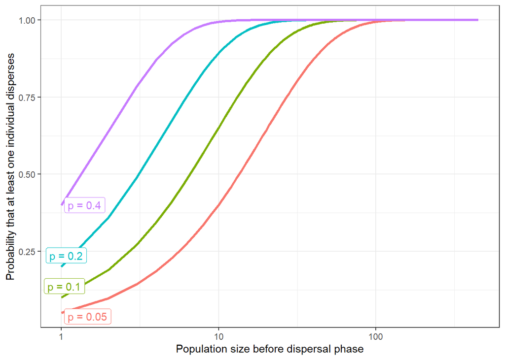

As a consequence, at the (relatively) low population sizes that interest us, reducing connectedness should lead expansions towards “pushed” dynamics, so two types of landscapes were set up: “control” dispersal, with two tubes connecting successive patches, and “restricted” dispersal, with only one tube. They were hypothesized to lead to **relatively** pulled and pushed dynamics, respectively. 12 landscapes were under putatively pushed dynamics, 12 under putatively pulled dynamics.

We have obtained two sources of information:

- **genetic information** is obtained by genotyping adult wasps every ~4 generations (release generation, G4,8,12) at 19 microsatellite loci.
- **population dynamics information** (population size and spread of the expansion) is obtained by photographing egg plates every generation right when they become brown-black if parasitized. Photographs are then analysed using ImageJ and Codicount to obtain estimated % of parasitism. Each image is analysed by 4 macros trained on different data ; images are scanned by humans prior to analyses, images with no black eggs are directly counted as zeros. In the main text of the manuscript (and the present document), we only use this file to get information on front location.

# Analysis

## Loading datasets

```r
###import raw datasets
raw_dynamics<- read_csv(here("data/Trichogramma_dynamics.csv"))

raw_genetics <- read_csv(here("data/Trichogramma_genetics.csv"),
                         col_types = cols(.default=col_character())
)
##forcing locus columns to be character otherwise some important leading zeroes are lost ( a 082082 individual _homozygote with two "082" alleles_ becomes 82082, 000000 becomes 0)
## there are other way to do it by doing it downscript (see e.g. stringr::str_pad()) but best to do it right at the outset
```

## Data preprocessing

We first play with the dynamics dataset. From the raw dataset we want to produce two ready-to-analyse datasets:

- 1. `data_G0`: used to estimate how many offspring are produced in “new” patches during the 1st generation. This allows us to check indirectly whether the setup truly limit connectedness. We can only do that at the start of the experiment as it is only then we know all parents were born/released in the same patch; afterward impossible to know how many parent patches contribute to these.
- 2. `data_front` : used to estimate how fast the wave fronts advance

We then generate the processed genetics dataset from the raw genetic dataset.

### Data validation dataset

```r
data_popsize_temp<- raw_dynamics %>%
  mutate(Mix= as.numeric(str_sub(Image,1,1)),
         Treatment = str_sub(Image,2,3),
         Replicate = as.numeric(str_sub(Image,4,4)),
         Patch = as.numeric(str_sub(Image,6,7))
  ) %>%
  #no further processing needed; we exploit the fact that chars 6&7 are either digit dot (patchs 0 to 9)
#or digit-digit (patches 10 and beyond)
## as.numeric() resolves both correctly (e.g; "2." and "12" become 2 and 12)
  mutate(landscapeID=paste("Mix",Mix,"_Treatment",Treatment,"_Replicate",Replicate,sep="")) %>%
  mutate(Peggs_est=P/(P+H), ## proportion of pixels counted as parasitised (estimated)
         spacetimeID=paste(landscapeID,"_Generation",Generation,"_Patch",Patch,sep=""), # a unique ID for each replicate x patch x generation combination
         Mix = factor(Mix)) %>%
  mutate(Treatment = fct_recode(Treatment,`control`="PL",`restricted connectedness`="PS"))
```

### Data G0 dataset

```r
###a subdataset only containing info on G0
data_G0 <- filter(data_popsize_temp,Generation==1 & Patch<=4) %>%
  ##only patches 0 to 4 are available at start (adding "Patch <=4" above should not be necessary, but it makes it explicit)
  select(landscapeID,Mix,Treatment,Patch,Peggs_est,Macro) %>%
  ungroup() %>%
  pivot_wider(.,names_from="Patch",values_from=c("Peggs_est"),names_prefix = "P") %>%
  filter(is.na(P0)==FALSE) %>%   ## remove the row with the one macro with missing info for "resident" eggs (can't estimate dispersal)
  mutate(P1=replace_na(P1,0)) %>%
  mutate(P2=replace_na(P2,0)) %>%
  mutate(P3=replace_na(P3,0)) %>%
  mutate(P4=replace_na(P4,0))  %>%
  mutate(Pall=(P0+P1+P2+P3+P4)) %>%
  mutate(distmean = (1*P1+2*P2+3*P3+4*P4) / Pall) %>%   ## mean distance from release
  mutate(jitteredTRT=jitter(as.numeric(factor(Treatment)))) %>% ## for pretty plotting
  group_by(landscapeID) %>% mutate(jitteredTRT=mean(jitteredTRT)) %>%  ##ensures same jitter for same measure from different macros
  ungroup()
```

### Data front data set

```r
data_front <- data_popsize_temp %>%
  group_by(landscapeID,Mix,Treatment,Generation) %>%
  summarise(front = max(Patch)) %>%
  ungroup() %>%
  group_by(landscapeID) %>%
  arrange(Generation) %>%
  complete(nesting(Mix,Treatment,landscapeID),
                       Generation=0:13,fill=list(front=0)) %>% ##just so we have a G0 x0 point (i.e. release) for the plots
  ungroup()
```

### data genetics dataset

Then we turn to the genetics data. We’re only going to generate one analysis dataset here, by converting individual microsatellite info into population/patch-level multilocus heterozygosity data, a measure of genetic diversity

```r
data_genetics<-raw_genetics %>%
  mutate( ### info on variables is contained in each sample ID
    Generation=str_extract(ID,"G0|G4|G8|G12"),
    Mix=str_extract(ID,"_1P|_2P|_3P"),
    Treatment=str_extract(ID,"PL|PS"),
    Replicate=str_extract(ID,"L_[:digit:]|S_[:digit:]"),
    Location=str_extract(ID,"C|F")
  ) %>%
  mutate(
    Generation=as.numeric(str_extract(Generation,"0|4|8|12")),
    Mix=as.numeric(str_extract(Mix,"1|2|3")),
    Replicate=as.numeric(str_extract(Replicate,"[:digit:]")),
    Location=fct_recode(Location,core="C",front="F")
  ) %>%
  mutate(Location=as.character(Location)) %>%
  mutate(Location=replace_na(Location,"origin")) %>% ## samples that are neither core nor front are from the origin
  mutate(Location=factor(Location),landscapeID=paste("Mix",Mix,"_Treatment",Treatment,"_Replicate",Replicate,sep="")) %>%
  mutate(spacetimeID=paste(landscapeID,"_Generation",Generation,"_Location",Location,sep=""))


###isolate the genetics markers ####NB: needs to decide how null alleles are treated, esp individuals with only null alleles
genmat<- df2genind(select(data_genetics,starts_with("P")),####all allelic colunns start with a "P"
            ncode=3,ind.names=data_genetics$ID,pop=data_genetics$spacetimeID) #ncode=3 bc 3 characters for one allele
#sum(rowSums(genmat@tab)<38) ## quality check: should be zero, indicating all individuals have 2 alleles for each of the 19 loci

###generate summary of all other columns ; one row = one sampled patch
data_genetics <- data_genetics %>%
  group_by(spacetimeID) %>%
  mutate(Nsampled = length(Location))%>%
  ungroup() %>%
  select(-starts_with("P"), -ID) %>%
  distinct() %>%
  inner_join(
    tibble(Hexp=Hs(genmat),spacetimeID=names(Hs(genmat)))
    ) %>%
  mutate(is.front=-0.5*(Location=="core")+0.5*(Location=="front"),
         Treatment=fct_recode(Treatment,`control`="PL",`restricted connectedness`="PS"))
```

## data analysis

### Data at G0

```r
mod_G0 <- brm(bf(distmean/4~0+Treatment+(1|Macro),
                 ###divided by 4 because it's the maximal possible distance possible at G0
        nlf(phi~1/invphi),
        invphi~1),
        data=data_G0,family=Beta(link_phi="identity"),
        iter=2000,chains=4,
        prior=c(
          set_prior("normal(0,1.5)",class="b"),
          set_prior("normal(0,1)",class="sd"),
          set_prior("normal(0,1)",nlpar="invphi",lb=0)
        ),
        control=list(adapt_delta=0.99),seed=42)
```

### front position

```r
bf_front <- bf(front~log((speedasym+(speedstart-speedasym)*exp(-(Generation-1)*rate))*Generation),
               ##Generation - 1 because moving the startspeed away from t0 (where it doesn't actually exist) to t1 stabilises everything
               nlf(rate~exp(lograte)),
               nlf(speedasym~exp(logspeedasym)),
               nlf(speedstart~exp(logspeedstart)),
           logspeedasym~0+Treatment+(1|1|landscapeID),
           logspeedstart~0+Treatment+(1|1|landscapeID),
           lograte~0+Treatment+(1|1|landscapeID),
           family=lognormal,nl=TRUE)

prior_front <- c(
          set_prior("normal(0,1)",nlpar=c("logspeedasym","logspeedstart"),class="b"),
          set_prior("normal(0,1)",nlpar=c("lograte"),class="b"),
          set_prior("normal(0,1)",nlpar=c("logspeedasym","lograte","logspeedstart"),class="sd"),
          set_prior("normal(0,1)",class="sigma"),
          set_prior("lkj(2)",class="cor")
        )

mod_front=brm(bf_front,
        data=subset(data_front,Generation>0),chains=Nchains,iter=Niter,warmup=Nwarmup,
        prior= prior_front,control=list(adapt_delta=0.95,max_treedepth=10),
        seed = 42)
```

### genetics !!

```r
prior_genetics=c(
  set_prior("normal(0,1.5)",nlpar=c("logitH0"),class="b"),
  set_prior("normal(0,1)",nlpar=c("logdecay"),class="b"),
  set_prior("normal(0,1)",nlpar=c("logdecay","logitH0"),class="sd"),
  set_prior("lkj(2)",class="cor")
)
bf_genetics=bf(Hexp~log(H0*exp(-decay*Generation)),
               nlf(H0~inv_logit(logitH0)),
               nlf(decay~exp(logdecay)/10),
               logitH0~1+(1|1|landscapeID),
               logdecay~0+Treatment+Treatment:is.front+(is.front|1|landscapeID),
               family=student("log"),nl=TRUE)

mod_genetics=brm(bf_genetics,
                 data=data_genetics,
                 chains=Nchains,iter=Niter*2,warmup=Nwarmup*2,
                 prior=c(prior_genetics,
                         set_prior("normal(0,1)",class="sigma"),
                         set_prior("gamma(2,0.1)",class="nu")),
                 seed=42,control=list(adapt_delta=0.8,max_treedepth=10)
)

#the gamma(2, 0.1) prior for nu follows again recommendations from the Stan wiki
#https://github.com/stan-dev/stan/wiki/Prior-Choice-Recommendations
```

But heterozygosity is always between 0 and 1. So why use a log-Student model, and not simply a Beta model?  
Well, we did both, and the former clearly outperforms the latter, maybe because it accounts better for rare outliers (which would be expected due to sampling before genotyping, and due to the expansion process itself):

```r
bf_genetics2=bf(Hexp~log(H0*exp(-decay*Generation)),
               nlf(H0~inv_logit(logitH0)),
               nlf(decay~exp(logdecay)/10),
               logitH0~1+(1|1|landscapeID),
               logdecay~0+Treatment+Treatment:is.front+(is.front|1|landscapeID),
               nlf(phi~1/invphi),
               invphi~1,
               family=Beta(link_phi="identity"),nl=TRUE)

mod_genetics2=brm(bf_genetics2,
                 data=data_genetics,
                 chains=Nchains,iter=Niter*2,warmup=Nwarmup*2,
                 prior=c(prior_genetics,
                         set_prior("normal(0,1)",nlpar="invphi",lb=0)),
                 seed=42,control=list(adapt_delta=0.8,max_treedepth=10)
)

loo_student <- loo(mod_genetics)
loo_beta <- loo(mod_genetics2,reloo=TRUE)
loo_compare(loo_student, loo_beta)
##despite beta a priori a better spec, student log has better predictive performance
##see https://mc-stan.org/bayesplot/reference/PPC-loo.html for further possibilities of investigation
#####
```

[output not shown]

still, by forcing H0 to be between 0 and 1 using a logit transformation, we still ensure no “weird” values (e.g. > 1) are predicted by the log-Student model

## postprocessing : plots and summaries

```r
newdata <- data_G0 %>%
  mutate(Macro=Macro[1]) %>%
  select(Macro, Treatment) %>%
  distinct()


data_G0_avg <- data_G0 %>%
  group_by(landscapeID,Treatment)%>%
  summarise(distmean=mean(distmean),
            jitteredTRT=mean(jitteredTRT)) %>% ungroup()

p1 <-newdata %>%
  add_fitted_draws(mod_G0,re_formula=NA) %>%
  ggplot()+
  stat_eye(aes(x=Treatment,y=.value*4,fill=Treatment),.width=c(0.66,0.95),slab_alpha=0.3) +
  geom_point(data=data_G0,aes(x=jitteredTRT,y=distmean,col=Treatment),fill="white",pch=21,alpha=0.8)+
  geom_point(data=data_G0_avg, aes(x=jitteredTRT,y=distmean,fill=Treatment),pch=21,size=2)+
  scale_x_discrete("")+
  scale_y_continuous("Mean egg-laying distance from release site (patches)",limits=c(0,1.9))+
  theme_bw()

p2<- newdata %>%
  add_fitted_draws(mod_G0,re_formula=NA) %>%
  ungroup() %>%
  compare_levels(variable=.value,by=Treatment) %>%
  ggplot()+
  stat_eye(aes(x=Treatment,y=.value*4),.width=c(0.66,0.95),fill="grey")+
  scale_x_discrete("",labels="")+
  scale_y_continuous("Difference between treatments",
                     limits=c(0,1.9)-4*invlogit(fixef(mod_G0)["Treatmentcontrol","Estimate"])) + ##so the "difference" subplot is aligned with the main
  geom_hline(yintercept=0, lty=2) +
  theme_bw()

p1 + p2 + plot_layout(guides="collect",widths=c(4,1)) & theme_bw() &
  theme(legend.position="none")


##show consistent macro-level bias even on distances
## data_G0 %>% group_by(landscapeID) %>% mutate(DD=mean(distmean)) %>% ggplot()+ geom_boxplot(aes(x=Macro,y=distmean/DD))
## that's because macro that overestimates parasitism rates will overestimates # of eggs in "other patches" so overestimate distances
```

```r
p1 <- data_front %>%
  ungroup() %>%
  mutate(landscapeID= landscapeID[1]) %>%
  select(Treatment,landscapeID) %>%
  distinct() %>%
  expand_grid(Generation=(1:130)/10) %>%
  add_fitted_draws(mod_front,re_formula=NA) %>%
  mutate(.value_front=.value) %>%
  group_by(Generation,Treatment) %>%
  ggplot()+
  geom_line(data=data_front,aes(x=Generation,y=front,group=landscapeID,col=Treatment))+
  stat_lineribbon(aes(x=Generation,y=.value_front,fill=Treatment),.width=0.95,alpha=0.25)+
  scale_y_continuous("Front location (patches from release)")+
  facet_wrap(~Treatment)



p2 <- data_front %>%
  ungroup() %>%
  mutate(landscapeID= landscapeID[1],Generation=1) %>%
  select(Treatment,landscapeID,Generation) %>%
  distinct() %>%
  add_fitted_draws(mod_front,nlpar="logspeedasym",re_formula=NA) %>%
  mutate(.value=exp(.value)) %>%
  ggplot()+
  geom_eye(aes(x=Treatment,y=.value,fill=Treatment),alpha=0.25)+
  scale_x_discrete("Landscape type")+
  scale_y_continuous("Asymptotic velocity (patches per generation, posterior)")

p1 + p2 + plot_annotation(tag_levels="A") + plot_layout(guides="collect",widths=c(2,1)) & theme_bw() &
  theme(legend.position="none")
```

```r
# The palette with grey:
cbPalette <- c("#999999", "#E69F00", "#56B4E9", "#009E73", "#F0E442", "#0072B2", "#D55E00", "#CC79A7")
# The palette with black:
cbbPalette <- c("#000000", "#E69F00", "#56B4E9", "#009E73", "#F0E442", "#0072B2", "#D55E00", "#CC79A7")

newdata=data_genetics %>%
  mutate(landscapeID = landscapeID[1]) %>%
  select(Treatment,is.front,Location,landscapeID) %>%
  distinct() %>%
  filter(is.front!=0) %>%
  expand_grid(Generation=c(0:120)/10) %>%
  add_fitted_draws(mod_genetics,re_formula=NA)

p1 <- ggplot(newdata)+
  stat_lineribbon(aes(x=Generation,y=.value,fill=Location),.width=c(0.66,0.95),alpha=0.3)+
  geom_point(data=data_genetics,aes(x=Generation+is.front,y=Hexp,bg=Location),pch=21,size=2)+
  scale_fill_manual(values=cbbPalette[c(3,2,1)])+
  scale_y_continuous(name = "Genetic diversity (Hexp)") +
  scale_x_continuous(name = "Generations since start") +
  facet_wrap(~Treatment)+
  theme_light()

##other version with lines
bind_rows(data_genetics,
          data_genetics %>% filter(Generation==0) %>% mutate(Location="front"),
          data_genetics%>% filter(Generation==0) %>% mutate(Location="core")) %>%
  filter(Location!="origin") %>%
  ggplot()+
  geom_line(aes(x=Generation,y=Hexp,group=paste(landscapeID,Location),col=Location))+
  stat_lineribbon(data=newdata,aes(x=Generation,y=.value,fill=Location),.width=c(0.66,0.95),alpha=0.3)+
  scale_fill_manual(values=cbbPalette[c(3,2,1)])+
  scale_colour_manual(values=cbbPalette[c(3,2,1)])+
  scale_y_continuous(name = "Genetic diversity (Hexp)") +
  scale_x_continuous(name = "Generations since start") +
  facet_wrap(~Treatment)+
  theme_light()

p2<- newdata %>% ungroup() %>%
  select(landscapeID,is.front,Location,Treatment,Generation) %>%
  filter(Generation==12) %>%
  distinct() %>%
  add_fitted_draws(mod_genetics,nlpar="logdecay",re_formula=NA) %>%
  mutate(.value=exp(.value)) %>%
  ggplot()+
  geom_eye(aes(x=Location,y=.value,fill=Location),alpha=0.25)+
  scale_fill_manual(values=cbbPalette[c(3,2,1)])+
  facet_wrap(~Treatment)+
  theme_light()+
  scale_y_continuous("Decay rate of genetic diversity (posterior)")

######### TO CHECK

## compare the decay at the core bw treatment
subset(newdata,Location=="core" & (Generation==0|Generation==12)) %>%
  group_by(Treatment) %>%
  compare_levels(.value,by=Generation,fun=`-`) %>%  ##minus is default function, can be change, these slanted quotes are important
  ungroup() %>%
  compare_levels(.value,by=Treatment) %>%
  ggplot()+
  geom_halfeyeh(aes(y=Treatment,x=.value))

## compare the decay at the front bw treatment
subset(newdata,Location=="front" & (Generation==0|Generation==12)) %>%
  group_by(Treatment) %>%
  compare_levels(.value,by=Generation,fun=`-`) %>%  ##minus is default function, can be change, these slanted quotes are important
  ungroup() %>%
  compare_levels(.value,by=Treatment) %>%
  ggplot()+
  geom_halfeyeh(aes(y=Treatment,x=.value))

p1/p2 +plot_annotation(tag_levels = "A")
```